# Multiple Myeloma

2023-09-27

# Multiple Myeloma (NCI Thesaurus Code: C3242)

Multiple Myeloma also called Plasma Cell Myeloma is a cancer of the monoclonal plasma cells and is known as the second most common hematologic malignancy. In a healthy individual, plasma cells typically constitute approximately 1% of the cell population within the bone marrow, whereas in a multiple myeloma patient, this percentage increases to more than 10%. Additionally hypercalcemia, renal insufficiency, anemia, bone lesions are consequences of the disease. There are numerous therapies but generally multiple myeloma is incurable. Initiation and the progression of Multiple Myeloma are highly dependent on complex genetic aberrations, like chromosomal translocations and other structural variants such as deletions, duplications, and insertions. [1](https://www.ncbi.nlm.nih.gov/pmc/articles/PMC6570407/) [2](https://www.ncbi.nlm.nih.gov/pmc/articles/PMC9225019/#:~:text=The%20most%20frequent%20sub%2Dclonal,short%20arm%20of%20chromosome%201)

## Access data from Progenetix

```r
library(pgxRpi)
freq <- pgxLoader(type='frequency', output='pgxfreq', filters ="NCIT:C3242")
freq$meta #meta data information
```

```
##         code               label sample_count
## 1 NCIT:C3242 Plasma Cell Myeloma          277
## 2      total                              277
```

```r
head(freq$data$`NCIT:C3242`)
```

```
##      filters reference_name   start     end gain_frequency loss_frequency no
## 1 NCIT:C3242              1       0  400000          7.220          6.137  1
## 2 NCIT:C3242              1  400000 1400000         14.079          5.776  2
## 3 NCIT:C3242              1 1400000 2400000         14.079          5.776  3
## 4 NCIT:C3242              1 2400000 3400000         11.191          6.137  4
## 5 NCIT:C3242              1 3400000 4400000         11.191          5.776  5
## 6 NCIT:C3242              1 4400000 5400000         10.108          6.137  6
```

# Visualisation

## Visualisation of the Genome:

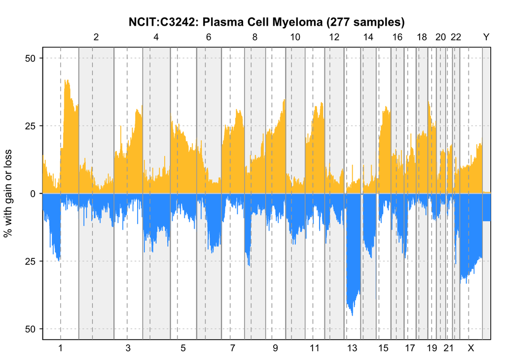

```r
pgxFreqplot(freq)
```

## Visualisation of Chromosomes: 1, 7, 9, 11, 13, 15, 19, X

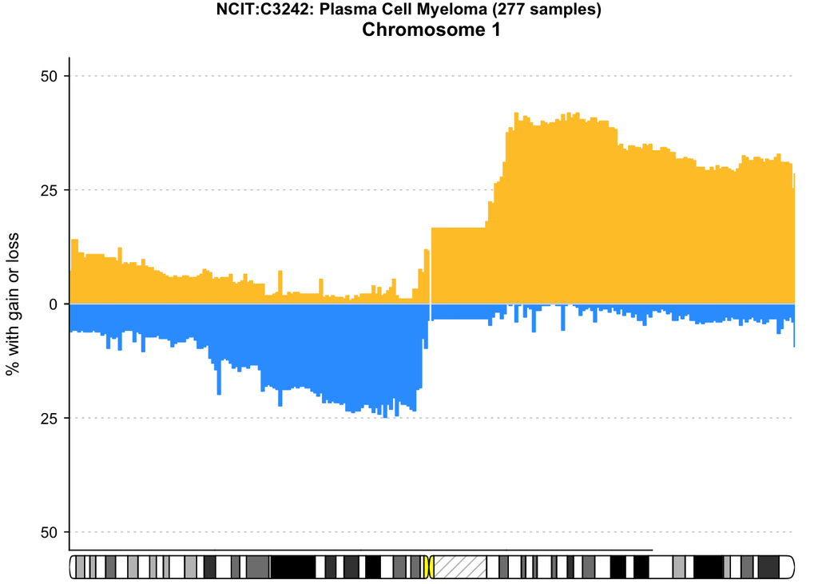

```r
pgxFreqplot(freq, chrom=1)
```

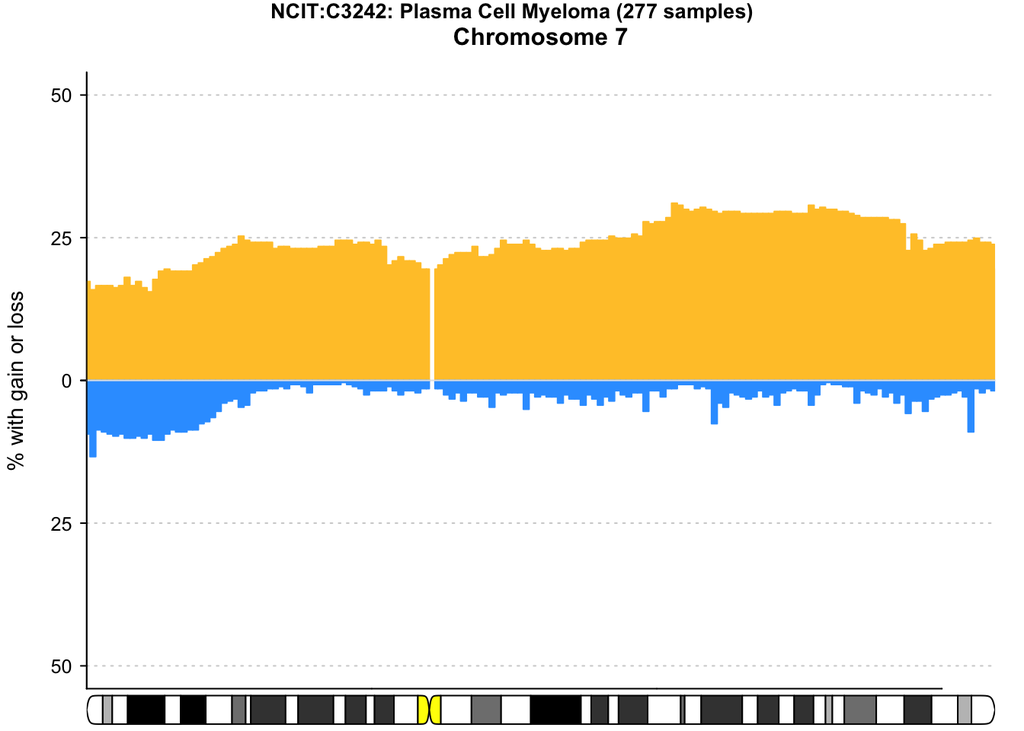

```r
pgxFreqplot(freq, chrom=7)
```

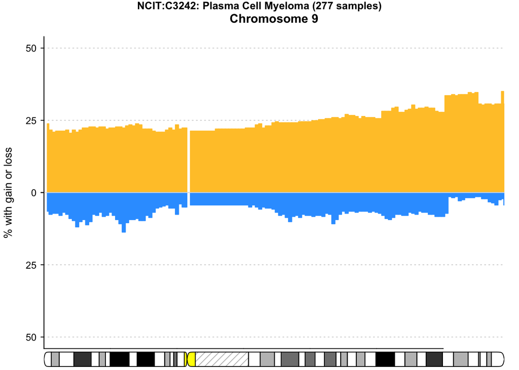

```r
pgxFreqplot(freq, chrom=9)
```

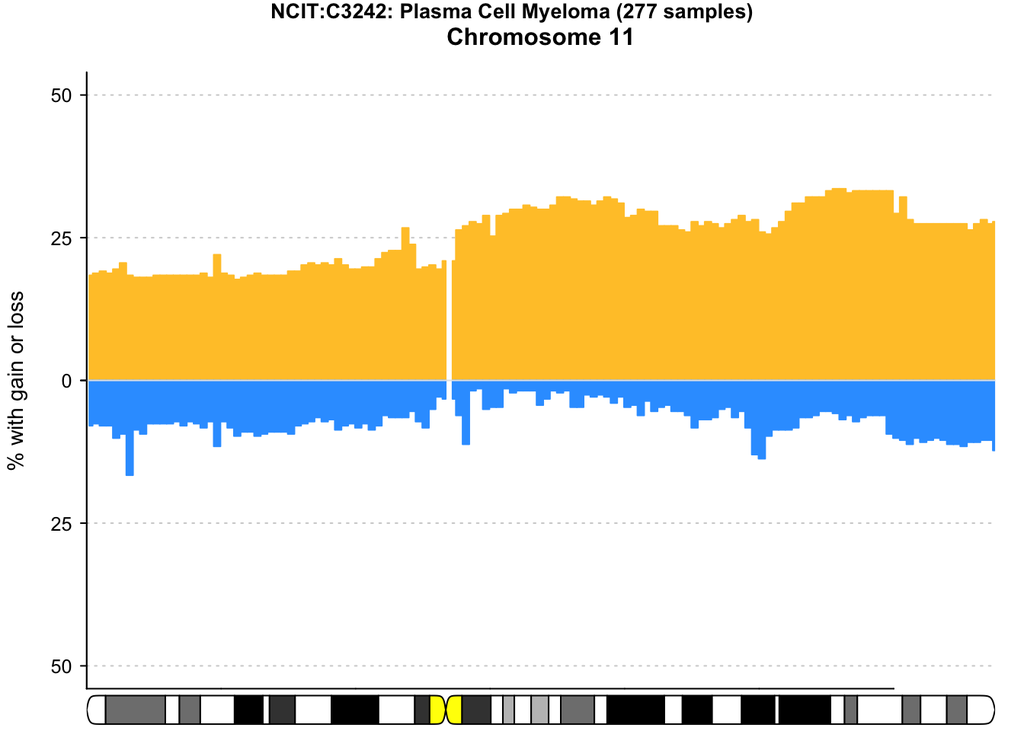

```r
pgxFreqplot(freq, chrom=11)
```

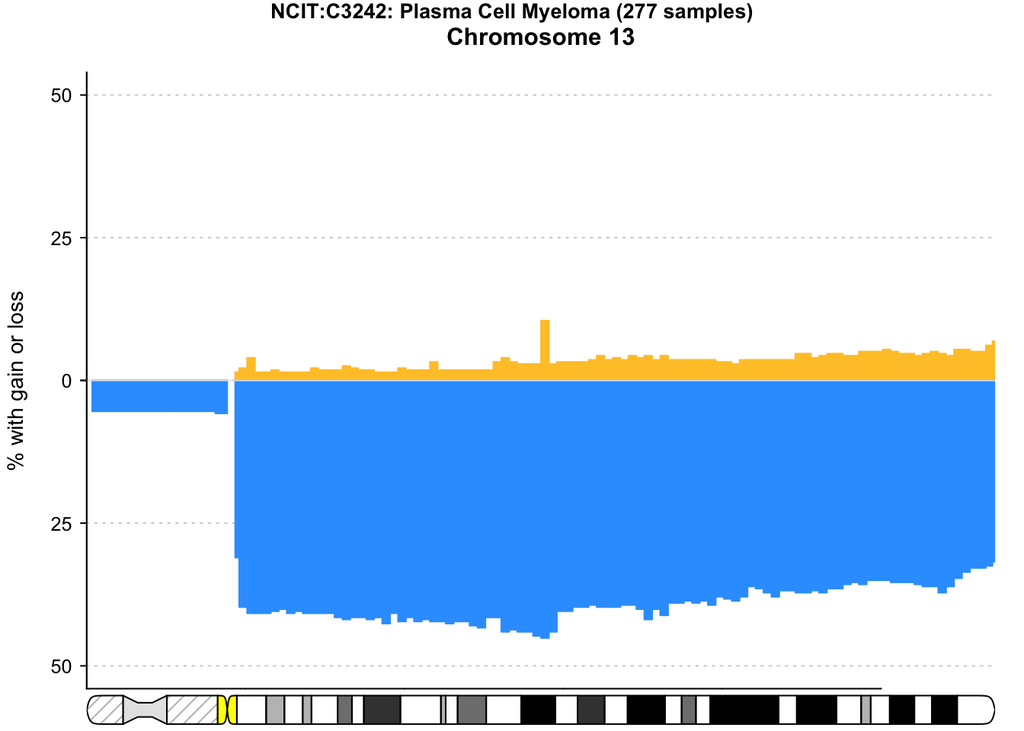

```r
pgxFreqplot(freq, chrom=13)
```

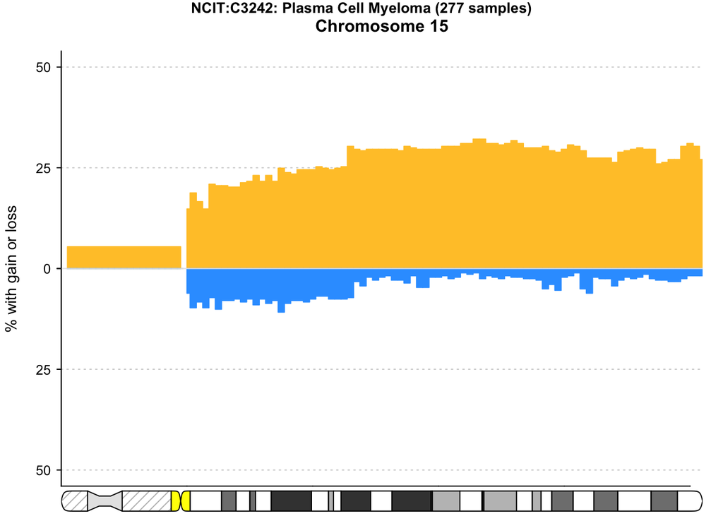

```r
pgxFreqplot(freq, chrom=15)
```

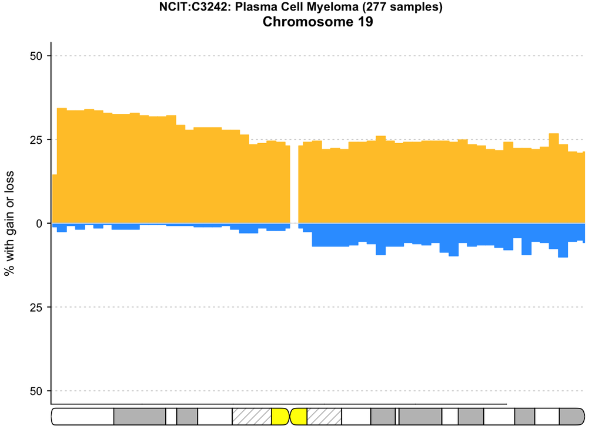

```r
pgxFreqplot(freq, chrom=19)
```

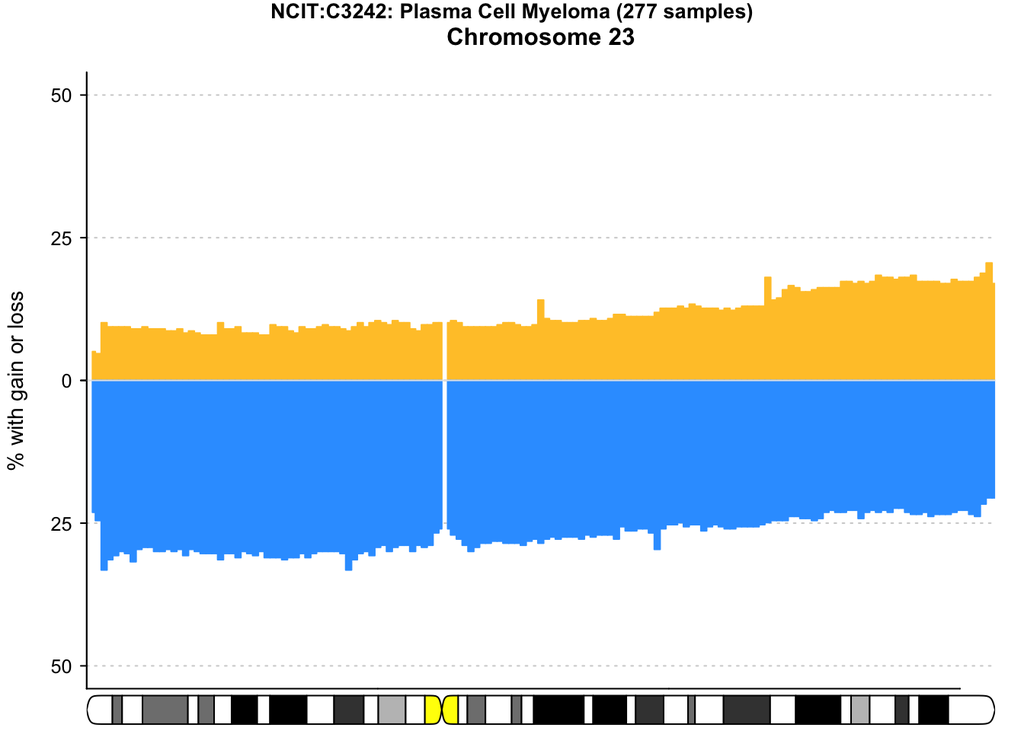

```r
pgxFreqplot(freq, chrom=23) # in this case the 23 specifies the X-Chromosome
```

According to the plots, there are frequent duplication on the 1q, 7q, 9q, 11q, 15q, 19p, 19q and frequent deletions on 13q, Xp, Xq (25% as a cutoff-value). The [Review of Multiple Myeloma Genetics including Effects on Prognosis, Response to Treatment, and Diagnostic Workup](https://www.ncbi.nlm.nih.gov/pmc/articles/PMC9225019/#:~:text=The%20most%20frequent%20sub%2Dclonal,short%20arm%20of%20chromosome%201) has also mentioned the gain of the long arm of chromosome 1 (gain 1q), the deletion of 13q arm (del(13q)). According to the Review the frequency of the duplication of the 1q arm is approximately 45% and the one of the deletion of 13q 40%. Concerning the deletion of Xp and Xq the study [Genomic Studies of Multiple Myeloma Reveal an Association Between X-Chromosome Alterations and Genomic Profile Complexity](https://orbi.uliege.be/bitstream/2268/202711/1/377.pdf) mentioned that complete or partial deletions were observed in about 47% and 17% of the female patients. The duplications on 7q, 9q, 11q, 15q, and chromosome 19 were not mentioned by these studies.